# Lecture 14: NHST

Data Analysis for Psychology in R 1

Tom Booth

Click for slides

## Today

- Discuss further details of NHST
- Introduce Type I error, Type II error, power and effect size

## Learning objectives

- Understand the structure of a hypothesis test.
- Understand the definition of Type I error, Type II error, power and effect size.

## Recap

- Structure of a Hypothesis Test
  1. A hypothesis
  2. A hypothesis test
  3. Test statistic
  4. Observed test statistic (point estimate from sample)
  5. Null distribution
  6. $p$-value
  7. Significance level

## NHST

- What we are setting out is the modern application of **N**ull **H**ypothesis **S**ignificance **T**esting (NHST).
- Before we continue to develop some of the key ideas, let’s briefly discuss where the framework came from.

## NHST: Brief history

- Jerzy Neyman (1894-1981) and Egon S. Pearson (1895-1980).
- **Key features:**
  - Argued that you need two hypotheses to compare, the null ($H_{0}$) and the alternative ($H_{1}$).
  - Rejected inductive reasoning for inductive behaviour
    - They wanted a decision rule.
  - Introduced concepts of Type I and Type II error
    - The different ways we can be wrong.
  - Focus was on decision making to maintain a long-run error rate.

## Decisions and errors

- Type I and Type II error:
  - N-P set up a 2x2 system.
  - We make a binary decision (right/wrong) about the $H_{0}$
  - Therefore, there are 2 ways to make the right decision, and two ways to make the wrong decision.

|  | $H_0$ is True | $H_0$ is False |
| --- | --- | --- |
| Fail to reject $H_0$ | Correct | Incorrect |
| Reject $H_0$ | Incorrect | Correct |

## Error rates: Type I

|  | $H_0$ is True | $H_0$ is False |
| --- | --- | --- |
| Fail to reject $H_0$ | Correct | Incorrect |
| Test rejects $H_0$ | Type I Error ($\alpha$) | Correct |

|  | $H_0$ is True | $H_0$ is False |
| --- | --- | --- |
| Fail to reject $H_0$ | Correct True Negative | Incorrect |
| Test rejects $H_0$ | Type I Error ($\alpha$) False Positive | Correct |

## What is alpha?

- $\alpha$ is commonly referred to as the significance level of the test.
  - It represents our level of tolerance for Type I error.
  - Or in the long-run, the number of times we are willing to be wrong.
  - Or probability of incorrectly rejecting the null.
- It is set a priori for any given hypothesis test.
  - The level at which $\alpha$ is set should be determined by study.
    - Conventionally this is set at .05 (5%); .01 (1%); or .001 (0.1%).

## Alpha and critical regions

- $\alpha$ defines a **critical region** under the sampling distribution.
  - The **critical value** is the value of the test statistic which defines the start of this region.

## Critical regions

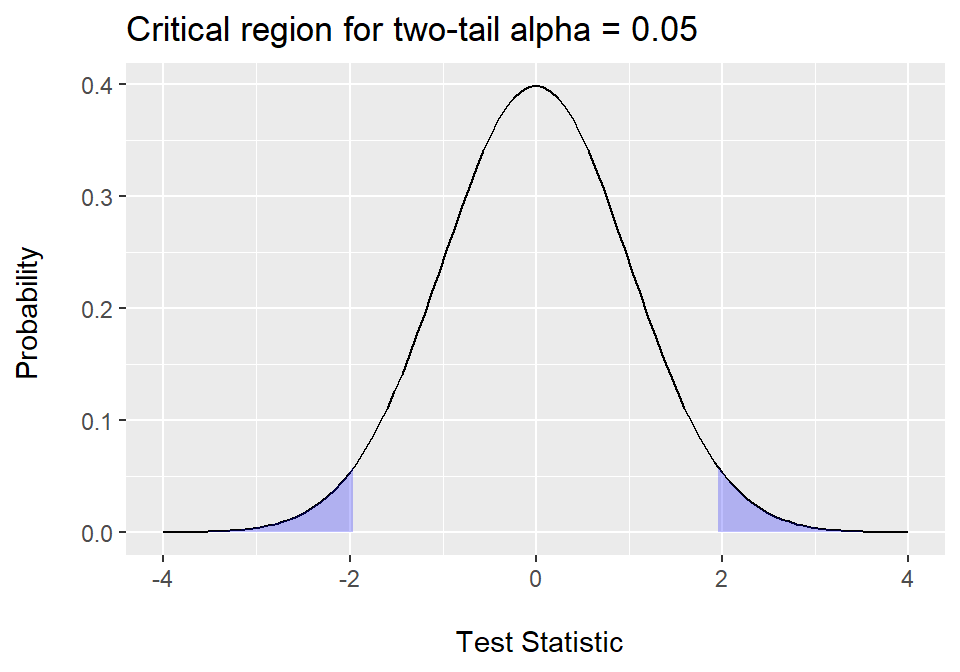

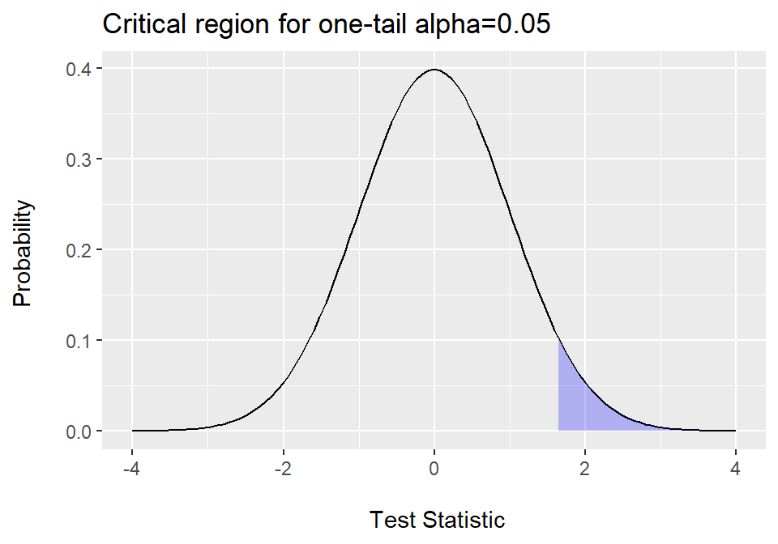

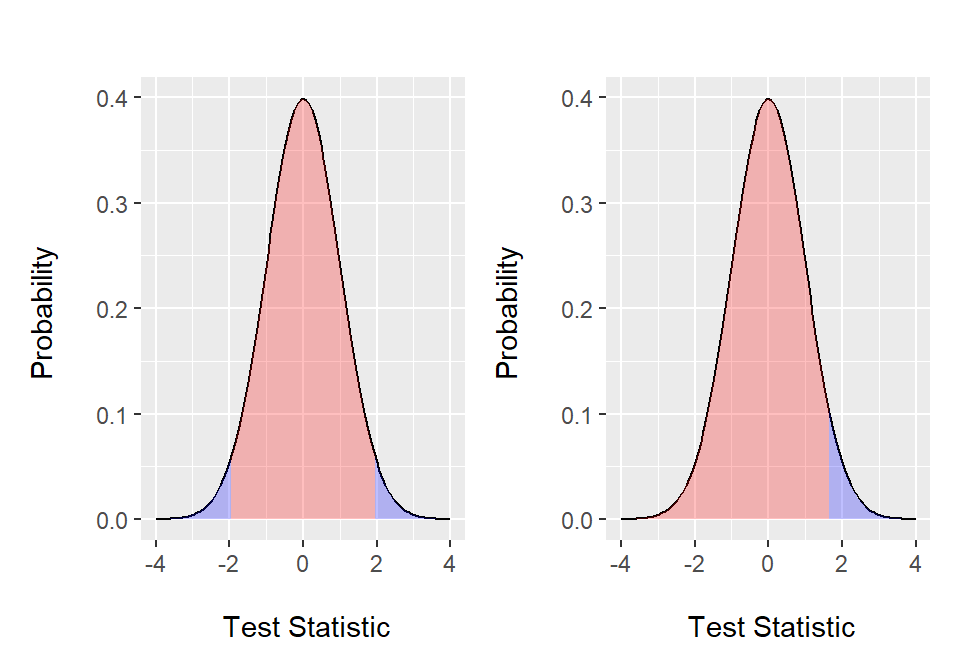

- In either case, 95% of the area is not within a critical region (red area in both plots).

## Error and probability

|  | $H_0$ is True | $H_0$ is False |
| --- | --- | --- |
| Fail to reject $H_0$ | $p(True Negative)=(1-\alpha)=0.95$ | Incorrect |
| Test rejects $H_0$ | $p(False Positive) = \alpha=0.05$ | Correct |
|  | $p =0.95+0.05=1$ |  |

## Error rates: Type II

|  | $H_0$ is True | $H_0$ is False |
| --- | --- | --- |
| Fail to reject $H_0$ | Correct True Negative | Type II Error ($\beta$) |
| Test rejects $H_0$ | Type I Error ($\alpha$) False Positive | Correct |

|  | $H_0$ is True | $H_0$ is False |
| --- | --- | --- |
| Fail to reject $H_0$ | Correct True Negative | Type II Error ($\beta$) False Negative |
| Test rejects $H_0$ | Type I Error ($\alpha$) False Positive | Correct True Positive |

## What are beta and power?

- $\beta$ is the level of tolerance for Type II error
  - Again, the number of times we are willing to be wrong.
  - The probability of incorrectly failing to reject the null.
- Power:
  - The probability of correctly rejecting the null when the null hypothesis is false.
  - Typically discuss a minimum power level of 80%.

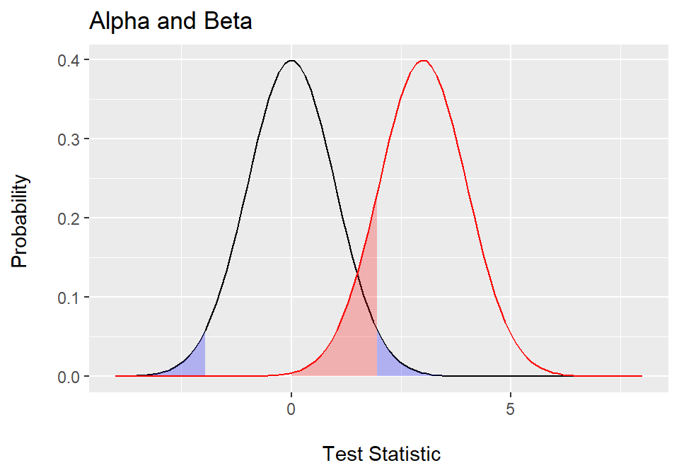

[output not shown]

## Effect size

- Imagine we have a null distribution for a statistic.
  - Let’s say the difference in means.
  - The null assumes no difference.
- How can I work out what would constitute a correct rejection of the null?
  - Or how big of a difference in means would there need to be for me to confidently reject the null?

## Effect size

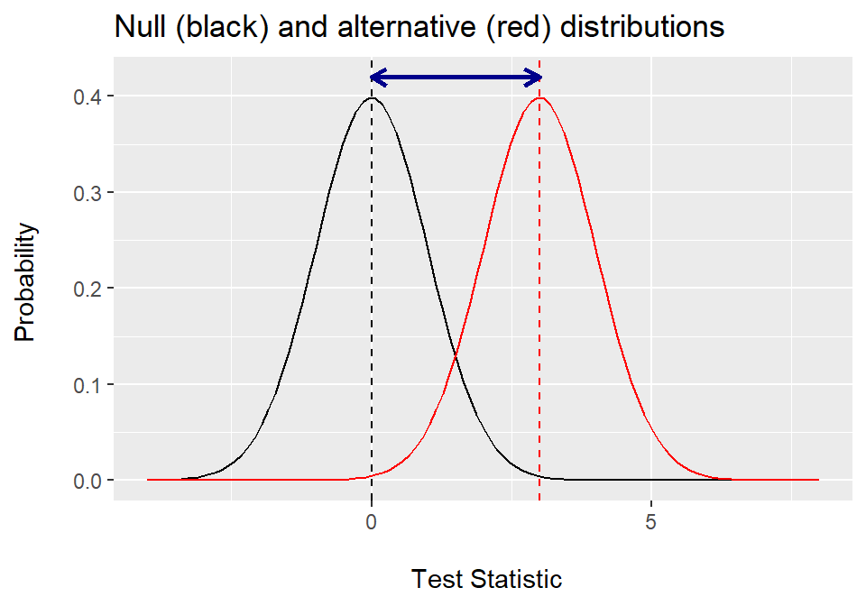

- This assumed (or hypothesized) difference from the null is known as an **effect size**.

## Full picture

|  | $H_0$ is True | $H_0$ is False |
| --- | --- | --- |
| Fail to reject $H_0$ | Confidence Level True Negative 1 - $\alpha$ | Type II Error ($\beta$) False Negative $1 - Power$ |
| Test rejects $H_0$ | Type I Error ($\alpha$) False Positive $1 - Conf.level$ | Power True Positive $1-\beta$ |

## Interplay of components

- Interplay of the 2x2 (from Szucs et al):
  - Set alpha level a priori
    - How many times in the long run I am willing to be wrong.
  - Decide on the effect size.
  - Decide on power based on acceptable Type II error rate.
  - From which we can select a sample size to keep power at this level given the set effect size.
- This you will look a lot more at in labs this week.

## Summary

- NHST provides decisions rules for our hypothesis tests.
- The null is either “right” or “wrong”
  - And given that, our decisions to reject or fail to reject, are “right” or “wrong”
- This gives a 2x2 system.
- Our probabilities of being wrong are Type I and Type II error.
- To fully define the system, we need to specify $\alpha$, $\beta$ thus power, and an effect size.

## Tasks for this week…

1. Finish tasks from last week.
2. Quiz 14: Hypothesis Testing and R
   - Today at 17:00.
   - Close Monday 3rd at 17:00

## Recommendations of the week

- Podcast: [Quantitude](https://quantitudethepodcast.org/)
- Recipe: [Spicy Baked eggs with tomato and chickpeas](https://www.deliciousmagazine.co.uk/recipes/spicy-baked-eggs-with-tomatoes-and-chickpeas/)
- Book: [Surely You’re Joking Mr Feynman](https://www.penguin.co.uk/books/1032177/surely-you-re-joking-mr-feynman/9780099173311.html), Richard Feynman.
- Thing to do: [Scottish Parliament](https://www.parliament.scot/visitandlearn/visiting-the-parliament.aspx)

## Additional Notes

- In the slides that follow, there is a brief outline of hypothesis testing as set out by Fisher.
- **This material is not tested in dapR1.**
- It is here purely for context.

## NHST: Critiques

1. We do not provide evidence for the null.
2. Testing leaves an theoretical black hole.
3. $p$-values do not provide probabilities of H0 or H1 being true.
4. NHST does not consider the pre-study probabilities of each hypothesis.
5. NHST hugely under-estimates false positives.
6. NHST is not structured to factor in accumulating evidence from science.

## Alternatives

- Likelihood (Fisher; see additional slides)
- Bayesian hypothesis testing
- We are not going to talk much about these approaches (not until 3rd year)
  - If you are interested, see additional readings.

## Defining concepts: Fisher

- Null hypothesis ($H_{0}$):
  - The null hypothesis is the only hypothesis in Fishers system.
  - It is stated precisely, such that a sampling distribution can be built.
  - Conventionally will specific a point, around which we would only expect to see random variation.
  - The term ?null? comes from the verb to nullify (invalidate).
- $p$-value:
  - Fisher rejected the idea that the information of interest was $P(H|data)$.
  - Instead his testing considered $P(data|H)$
    - That is, given a hypothesis which says something about the world, what is the probability of the data I see .
  - This probability was Fisher?s $p$-value.
  - Fisher saw the “**exact p-value as providing a heuristic piece of inductive evidence which gives an indication of the plausibility of H0 together with other available evidence**” ( Szucs et al. 2017)
    - The smaller the value, the more unusual or rare the sample statistic is.
- $p$-value:
  - Formal definition: *The probability of observing data as or more extreme if the null hypothesis is true.*
    - This definition stems from the fact that what we expect to see in data is defined by the specification of the null hypothesis and the associated sampling distribution.
  - Importantly, Fisher saw evidence of a small $p$-value from a single study as only weak evidence a phenomena may warrant further study.
  - A phenomena was only of interest if in well designed repeated studies small $p$-values were seen.
- Inductive reasoning:
  - System is based on an inductive reasoning.
  - There is not proof of the truth or a decision/outcome, it is just probable given information at hand.
  - If the null is true, we have a point estimate of the effect, and random variation around this.
    - We collect some data and calculate a statistic.
  - If it does not fall close to the value specified by the null, and is distant enough given random variation, then we have either witnessed a very rare event, or the null is incorrect.

## Steps: Fisher

- Pick the appropriate statistical test (rest of the course)
- Define the null hypothesis
- Calculate the probability of the data given the null ($p$-value).
- Assess the $p$-value. -Note Fisher arbitrarily spoke of values less than 0.05 as being potential markers for small $p$-values, but he was in no way fixed to them and they carried no particular statistical meaning.
- Come a conclusion.
  - Being careful your conclusions are in line with the underlying inductive reasoning and definition of the $p$-value.

## Additional Reading

- Berger, J.O. (2003). Could Fisher, Jeffreys and Neyman have Agreed on Testing? *Statistical Science, 18*, 1-32.
- Gigerenzer, G. (2004). Mindless statistics. *J. Socio Econ. 33*, 587–606.
- Hubbard, R. & Bayarri, M.J. (2003) Confusion Over Measures of Evidence (p’s) Versus Errors ($\alpha$s) in Classical Statistical Testing, *The American Statistician, 57*, 171-178.
- Lehmann, E.L. (1993). The Fisher, Neyman-Pearson Theories of Testing Hypotheses: One theory or two? *Journal of the American Statistical Association, 88*, 1242-1249
- Rouder, J.N., Morey, R.D., Verhagen, J., Province, J.M., & Wagenmakers E-J. (2016). Is there free lunch in inference? *Trends in Cognitive Science, 8*, 520-547.
- Szucs, D., & Ioannidis, J.P.A. (2017). When null hypothesis significance testing is unsuitable for research: A reassessment. *Frontiers in Human Neuroscience*, 11:390.